# Laboratory 3

Simulation, examples and exercises

L.Egidi

Spring 2018

# Weibull model

Let $y=(y_{1},\ldots, y_{n})$ a sample of iid values from a Weibull distribution, $Y \sim \mbox{We}(\gamma, \beta)$, with parameter $\theta=(\gamma, \beta)$ and density function:

$$f (y; \gamma, \beta)= \frac{\gamma}{\beta}\left(\frac{y}{\beta}\right)^{\gamma-1}e^{-(y/\beta)^{\gamma}}, \ \ \ y, \gamma, \beta >0,$$
where $\gamma$ is the *shape* parameter and $\beta$ is the *scale* parameter. Then, the likelihood is defined as:

$$L( \gamma, \beta ;y )=\prod_{i=1}^{n}L_{i}=\prod_{i=1}^{n}L(\gamma, \beta; y_{i}),$$
and the log-likelihood is defined as:

$$\begin{align*}
l(\gamma, \beta; y)= \log( \prod_{i=1}^{n}L_{i})= & n(\log(\gamma)-\log(\beta))- (\gamma-1)\sum_{i=1}^{n}\log(y_{i}/\beta)-\sum_{i=1}^{n}(y_{i}/\beta)^{\gamma} \\
= & n\log(\gamma)-n \gamma \log(\beta)+ \gamma\sum_{i=1}^{n}\log(y_{i})-\sum_{i=1}^{n}(y_{i}/\beta)^{\gamma}.
\end{align*}$$

We may write the log-likelihood function in $\mathsf{R}$:

```r
log_lik_weibull <- function( data, param){
  -sum(dweibull(data, shape = param[1], scale = param[2], log = TRUE))
}
```

## Plotting the log-likelihood

Suppose now to observe $n = 15$ failure times (expressed in days) of a sample of light bulbs: we assume $y_{1}, \ldots, y_{15} \sim \mbox{We}(\gamma, \beta)$, with $\gamma$ and $\beta$ unknown. We need to estimate them via maximum likelihood estimation. Preliminarily, we could inspect the log-likelihood function through **contour** plots.

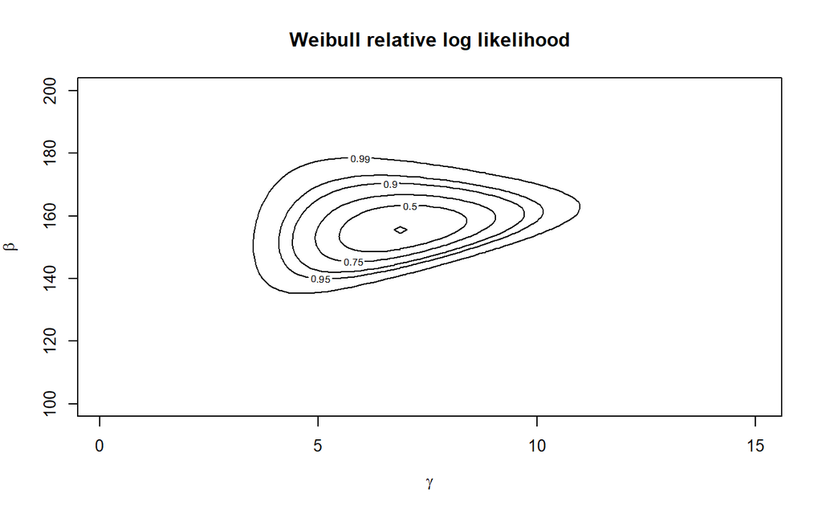

```r
y <- c(155.9, 200.2, 143.8, 150.1,152.1, 142.2, 147, 146, 146,
 170.3, 148, 140, 118, 144, 97)
n <- length(y)

 #define parameters grid
 gamma <- seq(0.1, 15, length=100)
 beta <- seq(100,200, length=100)
 parvalues <- expand.grid(gamma,beta)
 llikvalues <- apply(parvalues, 1, log_lik_weibull, data=y)
 llikvalues <- matrix(-llikvalues, nrow=length(gamma), ncol=length(beta),
 byrow=F)
 conf.levels <- c(0,0.5,0.75,0.9,0.95,0.99)

 #contour plot
 contour(gamma, beta, llikvalues-max(llikvalues),
 levels=-qchisq(conf.levels, 2)/2,
 xlab=expression(gamma),
 labels=as.character(conf.levels),
 ylab=expression(beta))
 title('Weibull relative log likelihood')
```

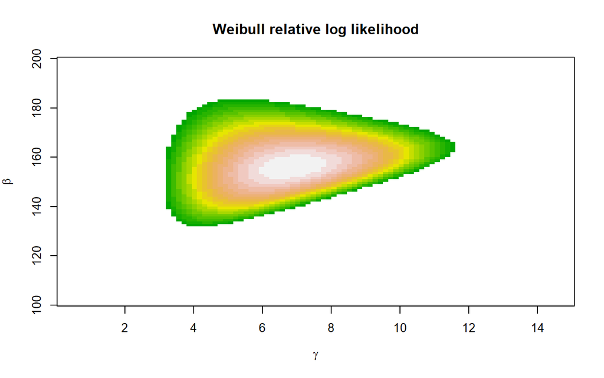

```r
 #image
 image(gamma,beta,llikvalues-max(llikvalues),zlim=c(-6,0),
 col=terrain.colors(20),xlab=expression(gamma),
 ylab=expression(beta))
 title('Weibull relative log likelihood')
```

## Parameter estimates

We may compute the maximum likelihood estimates $\hat{\gamma}, \hat{\beta}$ by equating at zero the log-likelihood derivatives:

$$\begin{align*}
\frac{\partial}{\partial \gamma}l(\gamma, \beta; y)= & \frac{n}{\gamma}-n \log(\beta)+ \sum_{i=1}^{n}\log(y_{i})-\sum_{i=1}^{n}(y_{i}/\beta)^{\gamma}\log( y_{i}/\beta) = 0 \\
\frac{\partial}{\partial \beta}l(\gamma, \beta; y)= & -\frac{n}{\beta} \gamma + \frac{\gamma} {\beta^{\gamma+1}} \sum_{i=1}^{n} y_{i}^{\gamma} = 0
\end{align*}$$

Solving the second equation we get the constrained estimate $\beta_{\gamma}= (\sum_{i=1}^{n} y^{\gamma}_{i}/n)^{1/\gamma}$. Substituting this in the first equation, we get

$$\frac{n}{\gamma}+\sum_{i=1}^{n} \log (y_{i})-n \frac{\sum_{i} y^{\gamma}_{i}\log(y_{i})}{\sum_{i} y^{\gamma}_{i}} =0$$

The last equation needs to be solved numerically.

```r
gammahat<-uniroot(function(x) n/x+sum(log(y))-n*
 sum(y^x*log(y))/sum(y^x),
 c(1e-5,15))$root
 betahat<- mean(y^gammahat)^(1/gammahat)
 weib.y.mle<-c(gammahat,betahat)
 #first element is the MLE for the shape gamma, second element the MLE for the scale beta
 weib.y.mle
```

```
## [1]   6.886215 155.948671
```

Of course, we are interested in assessing the variability and the consistency of our MLE estimators. Let $\theta=(\gamma, \beta)$ denote the bidimensional parameter vector. At this purpose, we may compute the **observed information** matrix
$$J(\theta; y)=- \frac{\partial^{2} l( \theta;y)}{ \partial \theta \partial \theta^{T}}.$$
Taking its inverse, evaluated in $(\hat{\gamma}, \hat{\beta})$, we obtain an estimate for the variance of our estimators. In what follow, we assume to have compute these quantities.

```r
 #observed information matrix
 jhat<-matrix(NA,nrow=2,ncol=2)
 jhat[1,1]<-n/gammahat^2+sum((y/betahat)^gammahat*
 (log(y/betahat))^2)
 jhat[1,2]<-jhat[2,1]<- n/betahat-sum(y^gammahat/betahat^(gammahat+1)*
 (gammahat*log(y/betahat)+1))
 jhat[2,2]<- -n*gammahat/betahat^2+gammahat*(gammahat+1)/
 betahat^(gammahat+2)*sum(y^gammahat)
 solve(jhat)
```

```
##          [,1]      [,2]
## [1,] 1.543250  2.550504
## [2,] 2.550504 38.406106
```

```r
 #se of the mle
 mle.se<-sqrt(diag(solve(jhat)))
 mle.se
```

```
## [1] 1.242276 6.197266
```

**Exercise 1** Compute analitically $J(\gamma, \gamma; y), J(\gamma, \beta; y), J(\beta, \beta; y)$.

**Exercise 2** Produce the contour plot for the **quadratic approximation** of the log-likelihood, based on the Taylor series:

$$l(\theta)-l(\hat{\theta}) \approx -\frac{1}{2} (\theta-\hat{\theta})^{T}J(\hat{\theta})(\theta-\hat{\theta}).$$

## Numerical optimization

So far, we used $\mathsf{R}$ simply as a pocket calculator, computing MLE and the variance of our estimators *analitically*, and then obtaining the numerical values just plugging into the formulas the inputs. However, as we have already seen with the MLE for $\gamma$, many times we do not have a closed form for MLE estimates and we may need **numerical optimization**. $\mathsf{R}$ provides various functions for performing numerical methods:

- $\mathsf{nlm()}$: minimizes a function using a Newton-type algorithm. It needs a starting value and does not allow constraints on the parameters. It is usually fast and reliable. It returns the ML estimate $\hat{\theta}$ ($\mathsf{estimate}$), the value of the likelihood $-l(\hat{\theta})$ ($\mathsf{minimum}$) and the hessian ($\mathsf{hessian}$), if $\mathsf{hessian = TRUE}$.
- $\mathsf{optim()}$: minimizes a function using Nelder-Mead, quasi-Newton and conjugate gradients algorithms. It includes an option for box-constrained optimization, and it requires a starting value. It returns the ML estimate $\hat{\theta}$ ($\mathsf{par}$) and the value of the likelihood $-l(\hat{\theta})$ ($\mathsf{value}$).
- $\mathsf{nlminb()}$: often is more stable, robust and reliable than $\mathsf{optim}$ (in particular with “nasty” functions). It performs only minimization and does not yield numerical derivatives as output. It returns the ML estimate $\hat{\theta}$ ($\mathsf{par}$) and the value of the likelihood $-l(\hat{\theta})$ ($\mathsf{objective}$).
- $\mathsf{optimize()}$: searches in an interval for a minimum or a maximum (if $\mathsf{maximum=TRUE}$) of a function. It returns the ML estimate $\hat{\theta}$ ($\mathsf{minimum}$) and the value of the likelihood $l(\hat{\theta})$ ($\mathsf{objective}$).

```r
weib.y.nlm<-nlm(log_lik_weibull,c(0,0),hessian=T,data=y)
```

A warning appears…for avoiding numerical warnings, we should work with a parameter **reparametrization**:

$$w= w(\theta)=(\log (\gamma), \log(\beta)).$$

Generally, for numerical purposes, it is convenient to reparameterize the model in such a way that the new parameter space is unbounded (in this case, $\theta = \theta(w)= (e^{\gamma}, e^{\theta})$). At such point, the parameters estimates will be espresseed in the log-scale, and we need to re-express them in the original scale:

```r
omega <- function(theta) log(theta)
theta <- function(omega) exp(omega)
log_lik_weibull_rep <- function(data, param) log_lik_weibull(data, theta(param))
weib.y.nlm<-nlm(log_lik_weibull_rep,c(0,0),hessian=T,data=y)
weib.y.nlm
```

```
## $minimum
## [1] 68.1784
##
## $estimate
## [1] 1.929516 5.049524
##
## $gradient
## [1] -6.635850e-06  2.089615e-05
##
## $hessian
##           [,1]      [,2]
## [1,]  34.53496 -51.49153
## [2,] -51.49153 708.83545
##
## $code
## [1] 2
##
## $iterations
## [1] 30
```

```r
theta(weib.y.nlm$estimate)
```

```
## [1]   6.886177 155.948219
```

```r
weib.y.mle
```

```
## [1]   6.886215 155.948671
```

The $\mathsf{optim()}$ function provides a lot of numerical methods, such us Nelder-Mead, quasi-Newton, conjugate-gradient methods and simulated annealings. As a drawback, the user has to set up very carefully the initial parameters and the adopted method, since the final solution may be quite sensitive to these choices…For computing the observed information, the function $\mathsf{optimHess()}$ computes numerical derivatives of generic functions.

```r
# gamma = 1, beta = 20 as initial choices with quasi-Newton method
weib.y.optim.qn <- optim(c(1,20), log_lik_weibull_rep, NULL, method =  "BFGS", data=y)$par
theta(weib.y.optim.qn)
```

```
## [1]   6.885195 155.946774
```

```r
# gamma = 1, beta = 6 as initial choices with conjugate-gradient method.
#quite inefficient...
weib.y.optim.cg <- optim(c(1,6), log_lik_weibull_rep, NULL, method =  "CG", data=y)$par
theta(weib.y.optim.cg)
```

```
## [1]   6.886169 155.948606
```

```r
optimHess(theta(weib.y.nlm$estimate),log_lik_weibull,data=y)
```

```
##             [,1]        [,2]
## [1,]  0.72788368 -0.04834062
## [2,] -0.04834062  0.02924794
```

```r
jhat
```

```
##            [,1]        [,2]
## [1,]  0.7278686 -0.04833690
## [2,] -0.0483369  0.02924752
```

**Exercise 3** Use $\mathsf{nlm}$ for computing the variance for the estimator $\hat{w}=(\log( \hat{\gamma}), \log(\hat{ \beta}))$ and $\mathsf{optimHess}$ for the variance of $\hat{\theta}=(\hat{\gamma}, \hat{ \beta})$.

## Profile likelihood

In practical situations, some components of the parameter vector $\theta$ are more important than others; essentially, in such situations it is of interest for us making inference only on those subgroups of parameters. In the Weibull case, we could treat $\gamma$ as the *parameter of interest* and $\beta$ as the *nuisance parameter*. We may then define the profile **log-likelihood**:

$$l_{P}(\gamma) = \underset{\beta}{\max}\ l(\gamma, \beta; y)= l(\gamma, \hat{\beta}_{\gamma}; y),$$
where $\hat{\beta}_{\gamma}$ is the *constrained* MLE for $\beta$, with $\gamma$ fixed. Some issues deserve a quick consideration:

- the profile log-likelihood is simply the log-likelihood for the bidimensional parameter $\theta$, with the nuisance component $\beta$ replaced by $\hat{\beta}_{\gamma}= (\sum_{i=1}^{n} y^{\gamma}_{i}/n)^{1/\gamma}$.
- $l_{P}$ is not a *genuine* likelihood. However, it has some nice features which ease to work with it.

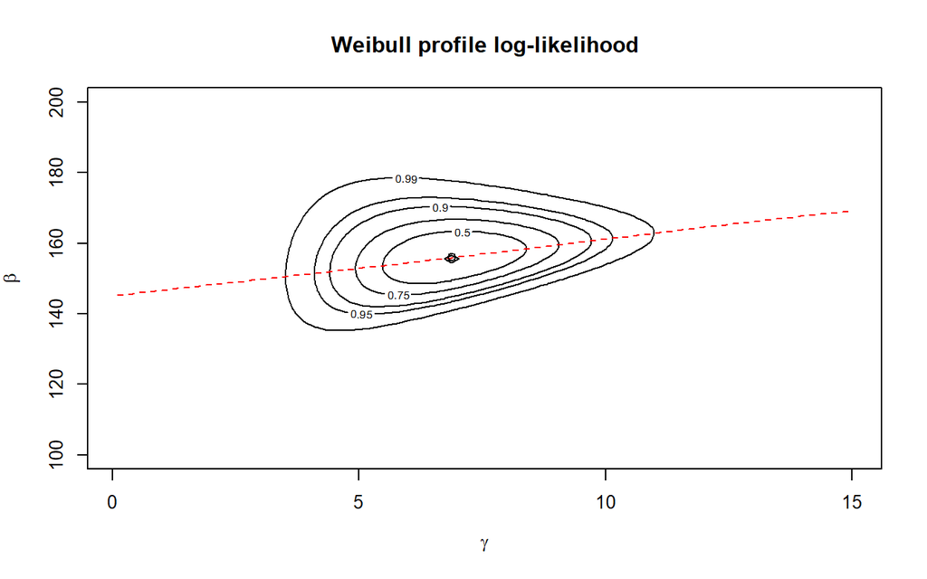

```r
 weib.y.mle<-optim(c(1,1),fn=log_lik_weibull,hessian=T,
 method='L-BFGS-B',lower=rep(1e-7,2),
 upper=rep(Inf,2),data=y)
 gamma <- seq(0.1, 15, length=100)
 beta <- seq(100,200, length=100)
 parvalues <- expand.grid(gamma,beta)
 llikvalues <- apply(parvalues, 1, log_lik_weibull, data=y)
 llikvalues <- matrix(-llikvalues, nrow=length(gamma), ncol=length(beta),
 byrow=F)
 conf.levels <- c(0,0.5,0.75,0.9,0.95,0.99)

 #contour plot
 contour(gamma, beta, llikvalues-max(llikvalues),
 levels=-qchisq(conf.levels, 2)/2,
 xlab=expression(gamma),
 labels=as.character(conf.levels),
 ylab=expression(beta))
 title('Weibull profile log-likelihood')

 beta.gamma<- sapply(gamma,function(x) mean(y^x)^(1/x))
 lines(gamma, beta.gamma, lty='dashed',col=2)
 points(weib.y.mle$par[1],weib.y.mle$par[2])
```

In some sense, we *reduced the dimension* of the problem, and we acknowledged that we may work with a one-dimensional likelihood evaluated in the constrained value $\hat{\beta}_{\gamma}$ for the nuisance component. Then, we may now compute some **deviance confidence intervals** with level $1-\alpha$ as:

$$\{ \gamma: l_{P}(\gamma) \ge l_{P}(\hat{\gamma})-\frac{1}{2}\chi^{2}_{1; 1-\alpha} \},$$
where $\chi^{2}_{1; 1-\alpha}$ is the $1-\alpha$-th quantile of a chi-squared distribution with 1 d.f, the asymptotic distribution for the **profile likelihood-ratio test statistic**:

$$W_{P}(\gamma)=2 \{ l_{P}(\hat{\gamma})-l_{P}(\gamma) \}.$$

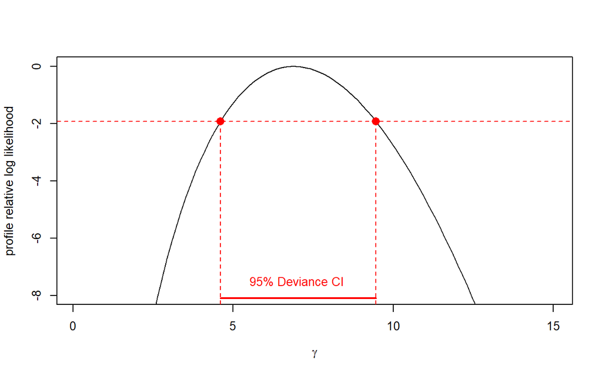

```r
log_lik_weibull_profile  <- function(data, gamma){
  beta.gamma <- mean(data^gamma)^(1/gamma)
 log_lik_weibull( data, c(gamma, beta.gamma) )
}

log_lik_weibull_profile_v <-Vectorize(log_lik_weibull_profile, 'gamma'  )

plot(function(x) -log_lik_weibull_profile_v(data=y, x)+weib.y.mle$value,
 from=0.1,to=15,xlab=expression(gamma),
 ylab='profile relative log likelihood',ylim=c(-8,0))
 conf.level<-0.95
 abline(h=-qchisq(conf.level,1)/2,lty='dashed',col=2)

 conf.level<-0.95
 lrt.ci1<-uniroot(function(x) -log_lik_weibull_profile_v(y, x)+
 weib.y.mle$value+
 qchisq(conf.level,1)/2,
 c(1e-7,weib.y.mle$par[1]))$root
 lrt.ci1<-c(lrt.ci1,uniroot(function(x) -log_lik_weibull_profile_v(y,x)+
 weib.y.mle$value+
 qchisq(conf.level,1)/2,
 c(weib.y.mle$par[1],15))$root)
 segments( lrt.ci1[1],-qchisq(conf.level,1)/2, lrt.ci1[1],
   -log_lik_weibull_profile_v(y, lrt.ci1[1]), col="red", lty=2  )
  segments( lrt.ci1[2],-qchisq(conf.level,1)/2, lrt.ci1[2],
    -log_lik_weibull_profile_v(y, lrt.ci1[2]), col="red", lty=2  )
  points(lrt.ci1[1], -qchisq(0.95,1)/2, pch=16, col=2, cex=1.5)
 points(lrt.ci1[2], -qchisq(0.95,1)/2, pch=16, col=2, cex=1.5)
  segments( lrt.ci1[1],
   -8.1, lrt.ci1[2],
    -8.1, col="red", lty =1, lwd=2  )
  text(7,-7.5,"95% Deviance CI",col=2)
```

**Exercise 4** The **Wald confidence interval** with level $1-\alpha$ is defined as:

$$\hat{\gamma} \pm z_{1-\alpha/2}j_{P}(\hat{\gamma})^{-1/2}.$$
Compute the Wald confidence interval of level 0.95 and plot the results.

**Exercise 5** Repeat the steps above —write the profile log-likelihood, plot it and find the deviance confidence intervals— considering this time $\gamma$ as a nuisance parameter and $\beta$ as the parameter of interest.

## Weibull vs Exponential

The Exponential distribution $\mbox{Exp}(\beta)$ is a particular case of the Weibull distribution, with $\gamma =1$. In fact, in such case the density of the Weibull becomes:

$$f(y; \beta) = \frac{1}{\beta}e^{-y/\beta},$$
which is an exponential distribution in the **scale parametrization**. Remember that in such exponential models $\hat{\beta}= \overline y = 146.7$. The MLE $\hat{\beta}$ in the Weibul model above was about 155.95. In some cases, an exponential model could be more appropriate than a Weibull model. Is this the case?

Let perform some qq-plots:

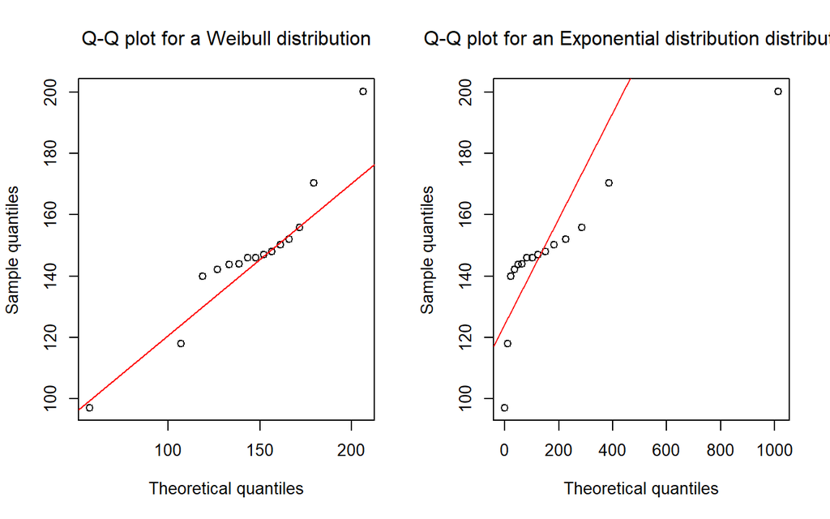

```r
par(mfrow=c(1,2))
qqplot(qweibull(ppoints(500), shape= weib.y.mle$par[1], scale = weib.y.mle$par[2]),y, main = expression("Q-Q plot for a Weibull distribution" ),
  ylab= "Sample quantiles", xlab = "Theoretical quantiles")
qqline( distribution = function(p) qweibull(p, shape= weib.y.mle$par[1], scale= weib.y.mle$par[2]),y,
       prob = c(0.1, 0.6), col = 2)
qqplot(qexp(ppoints(500), rate = 1/ mean(y)),y, main = expression("Q-Q plot for an Exponential distribution distribution" ),
  ylab= "Sample quantiles", xlab = "Theoretical quantiles")
qqline( distribution = function(p) qexp(p,  rate = 1/mean(y)),y,
       prob = c(0.1, 0.6), col = 2)
```

Using the relationship existing between confidence intervals and tests, we could also perform some **likelihood-based tests** using the profile-likelihood:

$$\begin{cases}
H_{0}: \gamma=1\\
H_{1}: \gamma \ne 1
\end{cases}$$

and computing the quantity:

$$\lambda_{P}(y)=\frac{L_{P}(\gamma_{1};y)}{L_{P}(\gamma_{0};y)}.$$
with rejection region:

$$\mathcal{R}_{\alpha}=\{ y: \lambda_{P}(y) \ge k_{\alpha} \}= \{y: l_{P}(\gamma;y) \le l_{P}(\hat{\gamma};y)- \frac{1}{2} \chi^{2}_{1, 1-\alpha} \}.$$

In terms of log-likelihood, we may use:

- the **likelihood ratio test**:

$$W_{P}(\gamma_{0})= 2 \{ l_{P}(\hat{\gamma}) -l_{P}(\gamma_{0}) \} \overset{\cdot}{\sim}\chi^{2}_{1}$$

- the **Wald test**:

$$We(\gamma_0)= \frac{\hat{\gamma}-\gamma_0}{\mbox{SE}(\hat{\gamma})^{2}}$$

```r
log_lik_exp <- function(data, param){
   beta.gamma <- mean(data^param)^(1/param)
  -sum(dexp(data, beta.gamma, log=TRUE))
}


statistic_test <- c()

 lambda_lrt <- -2*( log_lik_weibull_profile(y, weib.y.mle$par[1])-log_lik_exp(y,1))
 lambda_wald <- ((1/mle.se[1])^2)*(weib.y.mle$par[1]-1)^(2)

 p_lrt <- pchisq(lambda_lrt, df =1, lower.tail = FALSE)
 p_wald <- pchisq(lambda_wald,1, lower.tail = FALSE)

 statistic_test <- c(lambda_lrt, lambda_wald)
 p_values <- c(p_lrt, p_wald)

 statistic_test
```

```
## [1] 645399.37148     22.45101
```

```r
 p_values
```

```
## [1] 0.000000e+00 2.155718e-06
```

```r
  conf.level <- 0.95


 plot(function(x) -log_lik_weibull_profile_v(data=y, x)+weib.y.mle$value,
 from=0.1,to=15,xlab=expression(gamma),
 ylab = expression(l(gamma)-max(l(gamma))),ylim=c(-8,0))
 conf.level<-0.95
 abline(h=-qchisq(conf.level,1)/2,lty='dashed',col=2)

 conf.level<-0.95

 # deviance confidence intervals

 lrt.ci1<-uniroot(function(x) -log_lik_weibull_profile_v(y, x)+
 weib.y.mle$value+
 qchisq(conf.level,1)/2,
 c(1e-7,weib.y.mle$par[1]))$root
 lrt.ci1<-c(lrt.ci1,uniroot(function(x) -log_lik_weibull_profile_v(y,x)+
 weib.y.mle$value+
 qchisq(conf.level,1)/2,
 c(weib.y.mle$par[1],15))$root)

 # wald confidence intervals

 weib.y.se<-sqrt(diag(solve(weib.y.mle$hessian)))
  wald.ci1<-weib.y.mle$par[1]+c(-1,1)*qnorm(1-(1-conf.level)/2)*
  weib.y.se[1]
  wald.ci1
```

```
## [1] 4.451399 9.321032
```

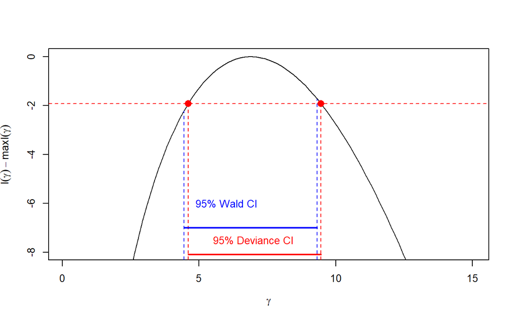

```r
 points(lrt.ci1[1], -qchisq(0.95,1)/2, pch=16, col=2, cex=1.5)
 points(lrt.ci1[2], -qchisq(0.95,1)/2, pch=16, col=2, cex=1.5)
 segments( lrt.ci1[1],-qchisq(conf.level,1)/2, lrt.ci1[1],
   -log_lik_weibull_profile_v(y, lrt.ci1[1]), col="red", lty=2  )
 segments( lrt.ci1[2],-qchisq(conf.level,1)/2, lrt.ci1[2],
    -log_lik_weibull_profile_v(y, lrt.ci1[2]), col="red", lty=2  )
 segments( lrt.ci1[1],
   -8.1, lrt.ci1[2],
    -8.1, col="red", lty =1, lwd=2  )
 text(7,-7.5,"95% Deviance CI",col=2)


   segments( wald.ci1[1],  -log_lik_weibull_profile_v(y,wald.ci1[1])-weib.y.mle$value,
      wald.ci1[1], -log_lik_weibull_profile_v(y, wald.ci1[1])+weib.y.mle$value, col="blue", lty=2  )
  segments( wald.ci1[2],-log_lik_weibull_profile_v(y,wald.ci1[2])-weib.y.mle$value,
      wald.ci1[2], -log_lik_weibull_profile_v(y, wald.ci1[2])+weib.y.mle$value, col="blue", lty=2  )
  segments(  wald.ci1[1], -7,  wald.ci1[2], -7, col="blue", lty =1, lwd=2  )

 text(6,-6,"95% Wald CI",col="blue")
```

**Exercise 6** Perform a test as above, but with:

$$\begin{cases}
H_{0}: \gamma=1\\
H_{1}: \gamma =5
\end{cases}$$

# Censored data

In some circumstances, such as **survival times**, the experimenter may not observe all data until their failures. For instance, in the bulb lights example above, we could specify a *censor* time, a sort of time threshold we may tolerate for observing our events. In the so called **type I censoring**, observations of lifetimes of $n$ units start at time 0 and the experiment is terminated at a fixed time $z_{0}$. At the end of the experiment, $R$ random units will be the *observed* failure units, with $R \le n$; the remaining unobserved $n-R$ units are sayd to be *censored*.

Given $T_1,\ldots, T_n$ the random survival times for the $n$ units, and $c_{1},\ldots, c_n$ some positive constants, our observations are $(Y_{i}, \delta_i)$, where:

$$\begin{align*}
Y_{i}=& \min \{T_i, c_i \}, \ i=1, \ldots,n \\
\delta_i =& I_{[0, c_i] (T_i)}
\end{align*}$$

We assume here that $T_1,\ldots, T_n$ are iid with marginal distribution $p_{T}(t, \theta)$ and cdf $F_{T}(t; \theta)$, with $t \in \mathcal{T} \subseteq \mathbb{R}^{+}, \ \theta \in \Theta \subseteq \mathbb{R}^{p}$. The likelihood for the type I censoring is then:

$$L(\theta)=\prod_{i=1}^{n} (1-F_{T}(t; \theta))^{1-\delta_i}p_{T}(y_{i}; \theta)^{\delta_i}.$$

The log-likelihood is then defined as:

$$l(\theta)= \sum_{1=1}^{n}(1-\delta_i) \log ( 1-F_{T}(t; \theta) )+ \sum_{i=1}^{n}\delta_i \log(p_{T}(y_{i}; \theta)).$$

## Censored normal data

Suppose that $x=(x_1,\ldots, x_n)$ is a type I censoring sample from a $\mathcal{N}(\theta,1)$ distribution, with censoring value $z_0$. Suppose our observations are $X_i= (Y_i, \delta_i)$, where $Y_{i}=\min(T_i, z_0)$, $T_i \sim \mathcal{N}(\theta,1)$, and $\delta_i=I(T_i <z_0)$. Then, the distribution of $(y_i, \delta_i)$ is:

$$f(x_i; \theta)= f(y_{i}, \delta_i; \theta)=\phi(y_i-\theta)^{\delta_i}\{(1-\Phi(z_0-\theta))\}^{1-\delta_i}$$

Then, the likelihood is:

$$L(\theta; y_i, \delta_i)=\prod_{i=1}^{n} \phi(y_i-\theta)^{\delta_i}\{(1-\Phi(z_0-\theta))\}^{1-\delta_i}$$
and the log_likelihood is:

$$l(\theta; y_i, \delta_i)= \sum_{i=1}^{n}{\delta_i}\phi(y_i-\theta)+(n-r)\{(1-\Phi(z_0-\theta))\},$$

where $r= \sum_{i}\delta_i$.

```r
log_lik_cens <- function( y, d, par){
  -sum(d*dnorm(y-par,log=TRUE) + (1-d)*pnorm(y-par,lower=FALSE,log=TRUE))
}

 n <- 40
 theta <- 4
 t <-rnorm(n, theta, 1)
 z_0 <- 4.5
 y <- c()
 delta <- c()
 for (i in 1:n){
   y[i] <- min(t[i], z_0)
      if (t[i]<=z_0){
         delta[i] <- 1
       }else{
         delta[i]<-0
   }
  }
 r <- sum(delta)
log_lik_cens_v <- Vectorize(log_lik_cens,"par")
plot(function(th) -log_lik_cens_v(y,delta, th),from=-2,to=8,xlab=expression(theta),
 ylab="log likelihood")

y.mle.cens <- nlm(log_lik_cens, 0, y = y, d = delta)
y.mle.cens
```

```
## $minimum
## [1] 51.27827
##
## $estimate
## [1] 4.019975
##
## $gradient
## [1] 5.30259e-10
##
## $code
## [1] 1
##
## $iterations
## [1] 5
```

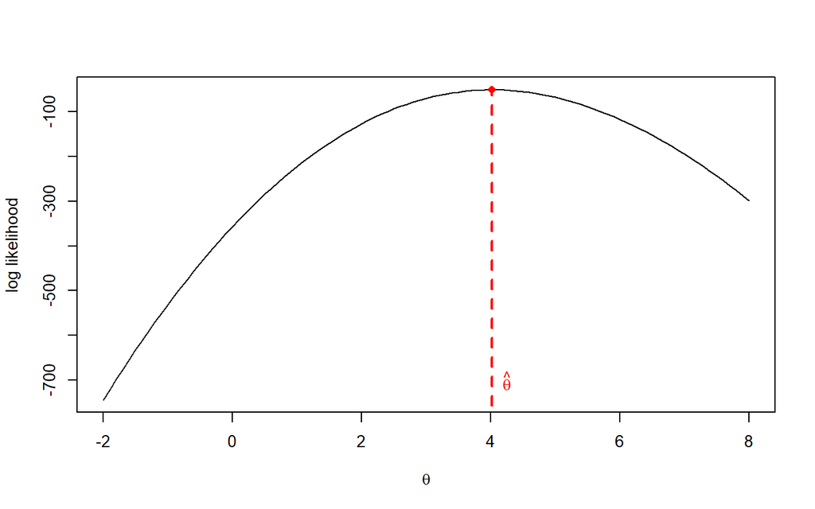

```r
segments(y.mle.cens$estimate,-800,
  y.mle.cens$estimate, -y.mle.cens$minimum, lwd=2, lty =2, col ="red")
points(y.mle.cens$estimate, -y.mle.cens$minimum, pch =16, bg ="red", col="red")
text(4.25, -700, expression(hat(theta)), col="red")
```

## EM algorithm

An iterative procedure for estimating $\theta$ in the model above is via the Expectation-Maximization (EM) algorithm. Here, we do not treat in depth, we just see a sketch. (For further details, see CS book, Section 5.2.3).

The log-likelihood based on the *augmented data* $(y_i, z_i)$ is:

$$l^{c}(\theta; y_i, z_i)= \sum_{i=1}^{n}\{ {\delta_i}\log(\phi(y_i-\theta))+(1-\delta_i)\log(\phi(z_i-\theta))\}.$$
The conditional distribuion of the missing data $z_1,\ldots, z_n$ given the observed data $y_1,\ldots,y_n$ is:

$$p(z_i |y_i; \theta)= \frac{p(y_i, z_i; \theta)}{p(y_i;\theta )}.$$
Taking the logarithm of this quantity leadts to the following relationship between the complete likelihood and the observed likelihood, namely:

$$l(\theta; y_i)= E_{\theta_0} [ l^{c} (\theta; y_i, z_i) ]- E_{\theta_0} [\log p(z_i |y_i; \theta)].$$
While we aim at maximizing the observed likelihood, only the first term is of intereet for us. Denoting:

$$Q(\theta| \theta_0,y)=E_{\theta_0} [ l^{c} (\theta; y_i, z_i) ],$$

the EM algorithm proceeds iteratively, maximizing $Q$ at each step, producing a sequence of estimators $\hat{\theta}_{(1)},\hat{\theta}_{(2)}, \ldots$, where $\hat{\theta}_{(j)}$ is the value of $\theta$ which maximizes $Q(\theta| \hat{\theta}_{(j-1)}, y)$, that is

$$Q(\hat{\theta}_{(j)}| \hat{\theta}_{(j-1)}, y)= \underset{\theta}{\max} Q(\theta| \hat{\theta}_{(j-1)}, y).$$
In this case we have; $Q(\theta |\theta_0, y)= -\frac{1}{2}\sum_{i=1}^{n}\{ {\delta_i}(\phi(y_i-\theta)^2+(1-\delta_i)E_{\theta_0}[(Z_i-\theta)^2]\},$ and :

$$\hat{\theta}_{(j+1)}= \frac{r}{n}\bar{y}_{r}+\frac{n-r}{n}\left[ \hat{\theta}_{(j)}+ \frac{ \phi(z_0-\hat{\theta}_{(j)}) }{1- \Phi(z_0-\hat{\theta}_{(j)})} \right].$$

```r
 ybar=mean(y[delta==1])
 theta=0
 eps=1e-5
 iter=1
 nonstop=TRUE
 p=r/n
 while (nonstop)
 {
 theta=c(theta,
 p*ybar+(1-p)*(theta[iter]+dnorm(z_0-theta[iter])/
 pnorm(z_0-theta[iter],lower=FALSE)))
 nonstop=(abs(diff(theta[iter:(iter+1)]))>eps)
 iter=iter+1
 }
 theta
```

```
## [1] 0.000000 3.854168 4.003898 4.018345 4.019809 4.019959 4.019974 4.019975
```